# Workshop 1: `ggplot2` and `dplyr`

### Try yourself

```r
roll |>
  filter(EthnicGroup == "International fee paying") |>
  filter(Level == "Year 13") |>
  arrange(desc(Students))
```

```
## # A tibble: 180 × 4
##    School                               EthnicGroup              Level  Students
##    <chr>                                <chr>                    <chr>     <dbl>
##  1 UP International College New Zealand International fee paying Year …       71
##  2 Rangitoto College                    International fee paying Year …       28
##  3 ACG Parnell College                  International fee paying Year …       22
##  4 Avondale College                     International fee paying Year …       22
##  5 Pakuranga College                    International fee paying Year …       21
##  6 Macleans College                     International fee paying Year …       20
##  7 Kerikeri High School                 International fee paying Year …       19
##  8 Howick College                       International fee paying Year …       17
##  9 Takapuna Grammar School              International fee paying Year …       16
## 10 Auckland Grammar School              International fee paying Year …       15
## # ℹ 170 more rows
```

1. Try doing a few of the above exercises utilising the pipe instead. i.e. all statements should start `roll |>`.

```r
roll |>
  filter(Level == "Year 9")
```

```
## # A tibble: 2,393 × 4
##    School                  EthnicGroup              Level  Students
##    <chr>                   <chr>                    <chr>     <dbl>
##  1 3H School International Pacific                  Year 9        1
##  2 3H School International Asian                    Year 9        1
##  3 A1 Student Limited      European                 Year 9        3
##  4 ACG Parnell College     Pacific                  Year 9        1
##  5 ACG Parnell College     Asian                    Year 9      158
##  6 ACG Parnell College     MELAA                    Year 9        4
##  7 ACG Parnell College     Other                    Year 9        1
##  8 ACG Parnell College     European                 Year 9       24
##  9 ACG Parnell College     International fee paying Year 9       11
## 10 ACG Strathallan         Māori                    Year 9        8
## # ℹ 2,383 more rows
```

```r
roll |>
  arrange(desc(Students))
```

```
## # A tibble: 66,261 × 4
##    School                                 EthnicGroup Level   Students
##    <chr>                                  <chr>       <chr>      <dbl>
##  1 Te Aho o Te Kura Pounamu               European    Year 12      800
##  2 Te Puna Wai o Waipapa - Hagley College European    Year 13      782
##  3 Te Aho o Te Kura Pounamu               European    Year 15      758
##  4 Te Aho o Te Kura Pounamu               European    Year 13      733
##  5 Te Aho o Te Kura Pounamu               European    Year 11      568
##  6 Te Aho o Te Kura Pounamu               European    Year 14      553
##  7 Te Aho o Te Kura Pounamu               Māori       Year 15      468
##  8 Te Aho o Te Kura Pounamu               Māori       Year 11      449
##  9 Te Aho o Te Kura Pounamu               Māori       Year 12      396
## 10 Macleans College                       Asian       Year 10      372
## # ℹ 66,251 more rows
```

The `select` command from `dplyr` allows you to select columns you wish to keep based on their name.

- Ranges can be used using `A:C` to pick columns A through C
- Columns can be removed through negation `-A`.
- `everything()` will return all remaining columns.
- `starts_with()` can be handy if you have several columns with a common prefix.

Try the following examples to understand what they do:

```r
roll |> select(School, EthnicGroup, Students)
```

```
## # A tibble: 66,261 × 3
##    School                  EthnicGroup Students
##    <chr>                   <chr>          <dbl>
##  1 3H School International Asian              1
##  2 3H School International Asian              2
##  3 3H School International European           1
##  4 3H School International Pacific            1
##  5 3H School International Asian              1
##  6 A1 Student Limited      European           1
##  7 A1 Student Limited      European           1
##  8 A1 Student Limited      European           2
##  9 A1 Student Limited      Asian              1
## 10 A1 Student Limited      European           2
## # ℹ 66,251 more rows
```

```r
roll |> select(-School, Number=Students)
```

```
## # A tibble: 66,261 × 3
##    EthnicGroup Level   Number
##    <chr>       <chr>    <dbl>
##  1 Asian       Year 10      1
##  2 Asian       Year 7       2
##  3 European    Year 7       1
##  4 Pacific     Year 9       1
##  5 Asian       Year 9       1
##  6 European    Year 10      1
##  7 European    Year 11      1
##  8 European    Year 4       2
##  9 Asian       Year 5       1
## 10 European    Year 5       2
## # ℹ 66,251 more rows
```

```r
roll |> select(Students, Level, everything())
```

```
## # A tibble: 66,261 × 4
##    Students Level   School                  EthnicGroup
##       <dbl> <chr>   <chr>                   <chr>
##  1        1 Year 10 3H School International Asian
##  2        2 Year 7  3H School International Asian
##  3        1 Year 7  3H School International European
##  4        1 Year 9  3H School International Pacific
##  5        1 Year 9  3H School International Asian
##  6        1 Year 10 A1 Student Limited      European
##  7        1 Year 11 A1 Student Limited      European
##  8        2 Year 4  A1 Student Limited      European
##  9        1 Year 5  A1 Student Limited      Asian
## 10        2 Year 5  A1 Student Limited      European
## # ℹ 66,251 more rows
```

### Try yourself

1. Rearrange the `roll` data set so that `Students` and `Level` are first.
2. Rename the `School` column to `Name` keeping all other columns.
3. Try part 2 using `rename` instead of `select`.

```r
#1
roll |> select(Students, Level, everything())
```

```
## # A tibble: 66,261 × 4
##    Students Level   School                  EthnicGroup
##       <dbl> <chr>   <chr>                   <chr>
##  1        1 Year 10 3H School International Asian
##  2        2 Year 7  3H School International Asian
##  3        1 Year 7  3H School International European
##  4        1 Year 9  3H School International Pacific
##  5        1 Year 9  3H School International Asian
##  6        1 Year 10 A1 Student Limited      European
##  7        1 Year 11 A1 Student Limited      European
##  8        2 Year 4  A1 Student Limited      European
##  9        1 Year 5  A1 Student Limited      Asian
## 10        2 Year 5  A1 Student Limited      European
## # ℹ 66,251 more rows
```

```r
#2
roll |> select(Name = School, everything())
```

```
## # A tibble: 66,261 × 4
##    Name                    EthnicGroup Level   Students
##    <chr>                   <chr>       <chr>      <dbl>
##  1 3H School International Asian       Year 10        1
##  2 3H School International Asian       Year 7         2
##  3 3H School International European    Year 7         1
##  4 3H School International Pacific     Year 9         1
##  5 3H School International Asian       Year 9         1
##  6 A1 Student Limited      European    Year 10        1
##  7 A1 Student Limited      European    Year 11        1
##  8 A1 Student Limited      European    Year 4         2
##  9 A1 Student Limited      Asian       Year 5         1
## 10 A1 Student Limited      European    Year 5         2
## # ℹ 66,251 more rows
```

```r
#3
roll |> rename(Name = School, Ethnicity = EthnicGroup) |> select(Name, everything())
```

```
## # A tibble: 66,261 × 4
##    Name                    Ethnicity Level   Students
##    <chr>                   <chr>     <chr>      <dbl>
##  1 3H School International Asian     Year 10        1
##  2 3H School International Asian     Year 7         2
##  3 3H School International European  Year 7         1
##  4 3H School International Pacific   Year 9         1
##  5 3H School International Asian     Year 9         1
##  6 A1 Student Limited      European  Year 10        1
##  7 A1 Student Limited      European  Year 11        1
##  8 A1 Student Limited      European  Year 4         2
##  9 A1 Student Limited      Asian     Year 5         1
## 10 A1 Student Limited      European  Year 5         2
## # ℹ 66,251 more rows
```

`mutate()` adds new variables using functions of existing columns. You can overwrite columns as well.

```r
roll |> mutate(Proportion = Students/sum(Students))
```

```
## # A tibble: 66,261 × 5
##    School                  EthnicGroup Level   Students Proportion
##    <chr>                   <chr>       <chr>      <dbl>      <dbl>
##  1 3H School International Asian       Year 10        1 0.00000120
##  2 3H School International Asian       Year 7         2 0.00000241
##  3 3H School International European    Year 7         1 0.00000120
##  4 3H School International Pacific     Year 9         1 0.00000120
##  5 3H School International Asian       Year 9         1 0.00000120
##  6 A1 Student Limited      European    Year 10        1 0.00000120
##  7 A1 Student Limited      European    Year 11        1 0.00000120
##  8 A1 Student Limited      European    Year 4         2 0.00000241
##  9 A1 Student Limited      Asian       Year 5         1 0.00000120
## 10 A1 Student Limited      European    Year 5         2 0.00000241
## # ℹ 66,251 more rows
```

```r
clean = roll |> mutate(Level = as.numeric(substring(Level, 6)))
```

### Try yourself

1. Using the `clean` dataset, create a new column combining ethnicgroup and level with `paste`.
2. Redo part 1, so that the original two columns are removed.
3. Create a new variable “Age” with the typical age of students in each year level (Year 1 students are typically 5 years old).
4. Investigate using the `unite` function from `tidyr` to do what you did in part 1 and 2.

```r
#1
roll |> mutate(Proportion = Students/sum(Students))
```

```
## # A tibble: 66,261 × 5
##    School                  EthnicGroup Level   Students Proportion
##    <chr>                   <chr>       <chr>      <dbl>      <dbl>
##  1 3H School International Asian       Year 10        1 0.00000120
##  2 3H School International Asian       Year 7         2 0.00000241
##  3 3H School International European    Year 7         1 0.00000120
##  4 3H School International Pacific     Year 9         1 0.00000120
##  5 3H School International Asian       Year 9         1 0.00000120
##  6 A1 Student Limited      European    Year 10        1 0.00000120
##  7 A1 Student Limited      European    Year 11        1 0.00000120
##  8 A1 Student Limited      European    Year 4         2 0.00000241
##  9 A1 Student Limited      Asian       Year 5         1 0.00000120
## 10 A1 Student Limited      European    Year 5         2 0.00000241
## # ℹ 66,251 more rows
```

```r
clean = roll |> mutate(Level = as.numeric(substring(Level, 6)))
clean |> mutate(EthLevel = paste(EthnicGroup, Level))
```

```
## # A tibble: 66,261 × 5
##    School                  EthnicGroup Level Students EthLevel
##    <chr>                   <chr>       <dbl>    <dbl> <chr>
##  1 3H School International Asian          10        1 Asian 10
##  2 3H School International Asian           7        2 Asian 7
##  3 3H School International European        7        1 European 7
##  4 3H School International Pacific         9        1 Pacific 9
##  5 3H School International Asian           9        1 Asian 9
##  6 A1 Student Limited      European       10        1 European 10
##  7 A1 Student Limited      European       11        1 European 11
##  8 A1 Student Limited      European        4        2 European 4
##  9 A1 Student Limited      Asian           5        1 Asian 5
## 10 A1 Student Limited      European        5        2 European 5
## # ℹ 66,251 more rows
```

```r
#2
clean |> mutate(EthLevel = EthnicGroup, Level) |>
  select(EthLevel, Students, School)
```

```
## # A tibble: 66,261 × 3
##    EthLevel Students School
##    <chr>       <dbl> <chr>
##  1 Asian           1 3H School International
##  2 Asian           2 3H School International
##  3 European        1 3H School International
##  4 Pacific         1 3H School International
##  5 Asian           1 3H School International
##  6 European        1 A1 Student Limited
##  7 European        1 A1 Student Limited
##  8 European        2 A1 Student Limited
##  9 Asian           1 A1 Student Limited
## 10 European        2 A1 Student Limited
## # ℹ 66,251 more rows
```

```r
#3
clean <- clean |>
  mutate(Age = Level + 4, EthLevel = EthnicGroup, Level) |>
  select(EthLevel, Age, School, Students)

#4
roll |> mutate(Proportion = Students/sum(Students))
```

```
## # A tibble: 66,261 × 5
##    School                  EthnicGroup Level   Students Proportion
##    <chr>                   <chr>       <chr>      <dbl>      <dbl>
##  1 3H School International Asian       Year 10        1 0.00000120
##  2 3H School International Asian       Year 7         2 0.00000241
##  3 3H School International European    Year 7         1 0.00000120
##  4 3H School International Pacific     Year 9         1 0.00000120
##  5 3H School International Asian       Year 9         1 0.00000120
##  6 A1 Student Limited      European    Year 10        1 0.00000120
##  7 A1 Student Limited      European    Year 11        1 0.00000120
##  8 A1 Student Limited      European    Year 4         2 0.00000241
##  9 A1 Student Limited      Asian       Year 5         1 0.00000120
## 10 A1 Student Limited      European    Year 5         2 0.00000241
## # ℹ 66,251 more rows
```

```r
clean = roll |> mutate(Level = as.numeric(substring(Level, 6)))
clean |> unite(EthLevel, EthnicGroup, Level)
```

```
## # A tibble: 66,261 × 3
##    School                  EthLevel    Students
##    <chr>                   <chr>          <dbl>
##  1 3H School International Asian_10           1
##  2 3H School International Asian_7            2
##  3 3H School International European_7         1
##  4 3H School International Pacific_9          1
##  5 3H School International Asian_9            1
##  6 A1 Student Limited      European_10        1
##  7 A1 Student Limited      European_11        1
##  8 A1 Student Limited      European_4         2
##  9 A1 Student Limited      Asian_5            1
## 10 A1 Student Limited      European_5         2
## # ℹ 66,251 more rows
```

The `summarise()` function reduces our dataset down to just a single row containing some summary. Try the following examples to understand what they do. Notice in the second example that we can use variables we’ve computed (`Total`) in other summaries.

```r
clean |> summarise(Rows = n())
```

```
## # A tibble: 1 × 1
##    Rows
##   <int>
## 1 66261
```

```r
clean |> summarise(Total = sum(Students), Average = Total/n())
```

```
## # A tibble: 1 × 2
##    Total Average
##    <dbl>   <dbl>
## 1 831038    12.5
```

### Try yourself

```r
#1
roll |>
  summarise(maxstudents = max(Students))
```

```
## # A tibble: 1 × 1
##   maxstudents
##         <dbl>
## 1         800
```

```r
#2
roll |>
  summarise(medianstudents = median(Students))
```

```
## # A tibble: 1 × 1
##   medianstudents
##            <dbl>
## 1              5
```

```r
#3
roll |>
summarise(min = min(Level), max = max(Level))
```

```
## # A tibble: 1 × 2
##   min    max
##   <chr>  <chr>
## 1 Year 1 Year 9
```

```r
#4
clean |>
  filter(EthnicGroup == "Māori") |>
  filter(Level == 9) |>
  summarise(sum(Students))
```

```
## # A tibble: 1 × 1
##   `sum(Students)`
##             <dbl>
## 1           17879
```

The true power of `dplyr` comes with the `group_by()` operation, which allows all of the rest of the operations we’ve learned about (plus more!) to be performed simultaneously on subgroups of the data.

The idea with `group_by()` is to collect rows together to be treated as a unit using one or more variables. All the other commands then operate per-group. For example, we can easily find the number of students per school by grouping by school and then adding up the number of students with `summarise`:

```r
clean |> group_by(School) |> summarise(Total = sum(Students))
```

```
## # A tibble: 2,534 × 2
##    School                  Total
##    <chr>                   <dbl>
##  1 3H School International     6
##  2 A1 Student Limited         22
##  3 ACG Parnell College      1682
##  4 ACG Strathallan          1111
##  5 ACG Sunderland            729
##  6 ACG Tauranga              387
##  7 ADDI Enrichment Academy    24
##  8 AGE School                 92
##  9 Abbotsford School         296
## 10 Aberdeen School           680
## # ℹ 2,524 more rows
```

### Try yourself

1. How many students of each ethnicity are there?
2. Which school has the most students in year 13?
3. Produce a graph of the total number of students by year level. Hint: First get the data frame you want, and then use `ggplot` with `geom_col`.

```r
#1
clean |> group_by(EthnicGroup)|> summarise(Total = sum(Students))
```

```
## # A tibble: 7 × 2
##   EthnicGroup               Total
##   <chr>                     <dbl>
## 1 Asian                    139908
## 2 European                 365471
## 3 International fee paying   6228
## 4 MELAA                     24264
## 5 Māori                    206123
## 6 Other                      6730
## 7 Pacific                   82314
```

```r
#2
clean |>
  filter( Level == 13) |>
  group_by(School) |>
  summarise(Total = sum(Students)) |>
  arrange(desc(Total))
```

```
## # A tibble: 553 × 2
##    School                                 Total
##    <chr>                                  <dbl>
##  1 Te Aho o Te Kura Pounamu                1248
##  2 Te Puna Wai o Waipapa - Hagley College  1214
##  3 Rangitoto College                        563
##  4 Mt Albert Grammar School                 515
##  5 Avondale College                         478
##  6 Macleans College                         466
##  7 Auckland Grammar School                  423
##  8 Burnside High School                     417
##  9 Epsom Girls Grammar School               407
## 10 Westlake Boys High School                392
## # ℹ 543 more rows
```

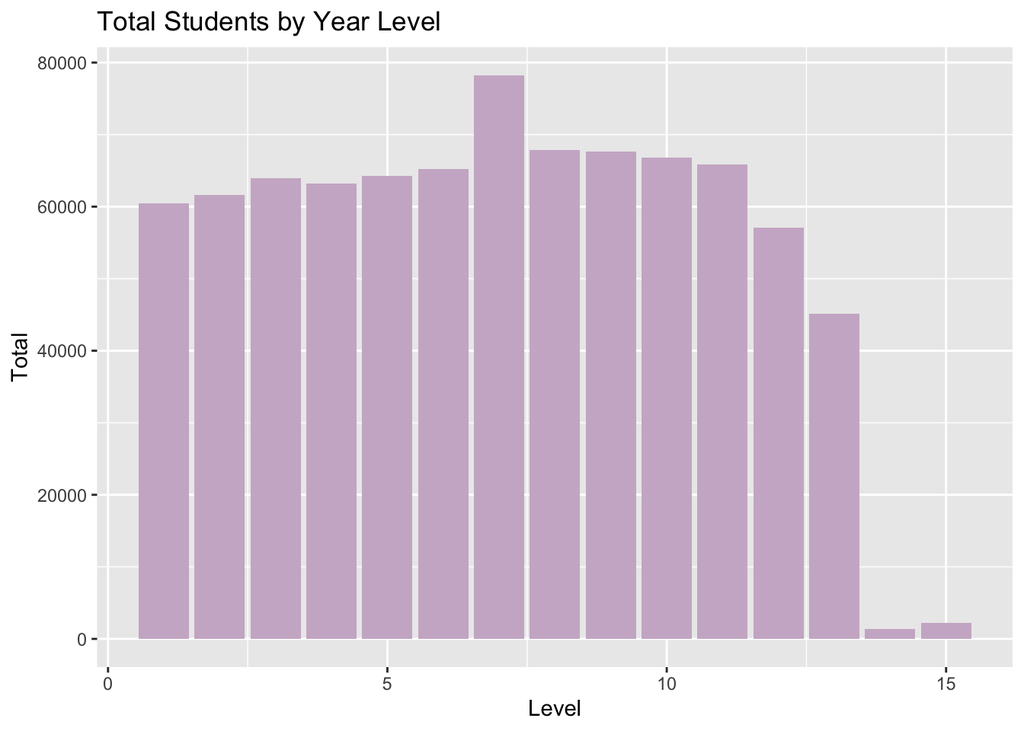

```r
#3
clean |>
  group_by(Level) |>
  summarise(Total = sum(Students)) |>
  ggplot(aes(x = Level, y = Total)) +
  geom_col(fill = 'thistle3') +
  labs(title = "Total Students by Year Level")
```

## Missing values

You probably noticed earlier that when plotting the `penguins` data, `ggplot` informed us that it had removed missing values. These are recorded as `NA` in R, and will need to be accounted for when summarising:

```r
penguins |> summarise(mean_flipper_length = mean(flipper_length_mm))
```

```
## # A tibble: 1 × 1
##   mean_flipper_length
##                 <dbl>
## 1                  NA
```

```r
penguins |> summarise(mean_flipper_length = mean(flipper_length_mm, na.rm=TRUE))
```

```
## # A tibble: 1 × 1
##   mean_flipper_length
##                 <dbl>
## 1                201.
```

Adding `na.rm=TRUE` to the `mean` function will fix this.

Another way that missing values can turn up is where they are **implicitly** missing. e.g. in the `clean` roll data, there are no `NA` entries at all, however there is missing data. e.g. if we tried to find the average number students of each level across schools, we might try[^3]:

```r
clean |> group_by(Level, School) |>
  summarise(Students = sum(Students)) |>
  group_by(Level) |>
  summarise(MeanStudents = mean(Students))
```

```
## `summarise()` has regrouped the output.
## ℹ Summaries were computed grouped by Level and School.
## ℹ Output is grouped by Level.
## ℹ Use `summarise(.groups = "drop_last")` to silence this message.
## ℹ Use `summarise(.by = c(Level, School))` for per-operation grouping
##   (`?dplyr::dplyr_by`) instead.
```

```
## # A tibble: 15 × 2
##    Level MeanStudents
##    <dbl>        <dbl>
##  1     1         30.2
##  2     2         30.8
##  3     3         31.8
##  4     4         31.5
##  5     5         32.0
##  6     6         32.5
##  7     7         35.5
##  8     8         45.2
##  9     9        120.
## 10    10        117.
## 11    11        118.
## 12    12        103.
## 13    13         81.7
## 14    14         14.3
## 15    15         36.1
```

However, this will be wrong, as there are no entries where the number of students in a category is 0, yet we know ofcourse that some schools will have no students of a particular level, such as primary schools who are unlikely to have year 13 students!

```r
clean |> filter(Students == 0)
```

```
## # A tibble: 0 × 4
## # ℹ 4 variables: School <chr>, EthnicGroup <chr>, Level <dbl>, Students <dbl>
```

We can see this by totalling up students by school and level, and then taking a look at some schools:

```r
clean |> group_by(Level, School) |>
  summarise(Students = sum(Students)) |>
  filter(str_detect(School, "Grammar")) |>
  arrange(School)
```

```
## `summarise()` has regrouped the output.
## ℹ Summaries were computed grouped by Level and School.
## ℹ Output is grouped by Level.
## ℹ Use `summarise(.groups = "drop_last")` to silence this message.
## ℹ Use `summarise(.by = c(Level, School))` for per-operation grouping
##   (`?dplyr::dplyr_by`) instead.
```

```
## # A tibble: 38 × 3
## # Groups:   Level [13]
##    Level School                         Students
##    <dbl> <chr>                             <dbl>
##  1     9 Auckland Girls' Grammar School      217
##  2    10 Auckland Girls' Grammar School      237
##  3    11 Auckland Girls' Grammar School      244
##  4    12 Auckland Girls' Grammar School      191
##  5    13 Auckland Girls' Grammar School      168
##  6     9 Auckland Grammar School             497
##  7    10 Auckland Grammar School             554
##  8    11 Auckland Grammar School             581
##  9    12 Auckland Grammar School             521
## 10    13 Auckland Grammar School             423
## # ℹ 28 more rows
```

One fix for this is using the `complete()` function from `tidyr`. This adds additional combinations to the data, though note that we will need to `ungroup()` things first, so that it can operate across the levels simultaneously[^4]:

```r
clean |> group_by(Level, School) |>
  summarise(Students = sum(Students)) |>
  ungroup() |>
  complete(Level, School) |>
  filter(str_detect(School, "Grammar")) |>
  arrange(School)
```

```
## `summarise()` has regrouped the output.
## ℹ Summaries were computed grouped by Level and School.
## ℹ Output is grouped by Level.
## ℹ Use `summarise(.groups = "drop_last")` to silence this message.
## ℹ Use `summarise(.by = c(Level, School))` for per-operation grouping
##   (`?dplyr::dplyr_by`) instead.
```

```
## # A tibble: 105 × 3
##    Level School                         Students
##    <dbl> <chr>                             <dbl>
##  1     1 Auckland Girls' Grammar School       NA
##  2     2 Auckland Girls' Grammar School       NA
##  3     3 Auckland Girls' Grammar School       NA
##  4     4 Auckland Girls' Grammar School       NA
##  5     5 Auckland Girls' Grammar School       NA
##  6     6 Auckland Girls' Grammar School       NA
##  7     7 Auckland Girls' Grammar School       NA
##  8     8 Auckland Girls' Grammar School       NA
##  9     9 Auckland Girls' Grammar School      217
## 10    10 Auckland Girls' Grammar School      237
## # ℹ 95 more rows
```

We can also fill in these missing values, because we know they should be 0.

### Try yourself

1. Add the necessary code above to fill in the `NA` values to be `0`. You can do this using the `fill` parameter of `complete`, or alternatively the `replace_na()` function.

```r
clean |>
  group_by(Level, School) |>
  summarise(Students = sum(Students), .groups = "drop") |>
  complete(Level, School, fill = list(Students = 0)) |>
  filter(str_detect(School, "Grammar")) |>
  arrange(School)
```

```
## # A tibble: 105 × 3
##    Level School                         Students
##    <dbl> <chr>                             <dbl>
##  1     1 Auckland Girls' Grammar School        0
##  2     2 Auckland Girls' Grammar School        0
##  3     3 Auckland Girls' Grammar School        0
##  4     4 Auckland Girls' Grammar School        0
##  5     5 Auckland Girls' Grammar School        0
##  6     6 Auckland Girls' Grammar School        0
##  7     7 Auckland Girls' Grammar School        0
##  8     8 Auckland Girls' Grammar School        0
##  9     9 Auckland Girls' Grammar School      217
## 10    10 Auckland Girls' Grammar School      237
## # ℹ 95 more rows
```

2. With the `NA` values replaced, recompute the mean number of students by level across all schools.

```r
clean |>
  group_by(Level, School) |>
  summarise(Students = sum(Students))|>
  ungroup()|>
  complete(School, Level, fill=list(Students = 0)) |>
  group_by(Level) |>
  summarise(meanstudents = mean(Students))
```

```
## `summarise()` has regrouped the output.
## ℹ Summaries were computed grouped by Level and School.
## ℹ Output is grouped by Level.
## ℹ Use `summarise(.groups = "drop_last")` to silence this message.
## ℹ Use `summarise(.by = c(Level, School))` for per-operation grouping
##   (`?dplyr::dplyr_by`) instead.
```

```
## # A tibble: 15 × 2
##    Level meanstudents
##    <dbl>        <dbl>
##  1     1       23.8
##  2     2       24.3
##  3     3       25.2
##  4     4       24.9
##  5     5       25.4
##  6     6       25.7
##  7     7       30.9
##  8     8       26.8
##  9     9       26.7
## 10    10       26.4
## 11    11       26.0
## 12    12       22.5
## 13    13       17.8
## 14    14        0.559
## 15    15        0.883
```

[^1]: A common issue is loading `MASS` after `dplyr` - the `MASS::select()` function then overrides `dplyr::select()` which results in very opaque error messages when you try and `select()` columns from a `data.frame`.
[^2]: This is an example of the *bias-variance trade-off*. By smoothing more we will reduce the variance of the estimate (as we’re estimating the density at each location by using more of the data) but will increase bias (as the estimate depends on points far away from the location). Conversely, by smoothing less we decrease bias (the estimate depends only on points nearby) but increase variance (we’re using fewer points to estimate at each location). At some point we have a sweet spot! We’ll see this same principle over and over in this course.
[^3]: Note that the second `group_by(Level)` here is not required: After we `summarise()`, the second group (`School`) is automatically stripped, as we only have one row for that (as we’ve summarised across the different schools now). So the grouping will have already dropped down to `Level`. Note that `summarise()` will tell you this.
[^4]: You can also ungroup by adding the `group="drop"` to the `summarise()` command.